# Clean_vert_growth

Carmen

April 16, 2019

# Load data

```r
setwd("~/../Shrubs-Seedlings/code/FireFootprints_analysis/")
load(file="../../compiled_data/fire_footprints/master_seedlings2.Rdata")
```

# Take out species that aren’t PIPO or ABCO

```r
df <- df %>% filter(Species %in% c("PIPO", "ABCO"))
```

# Calculate 2015 height values

## Calculate 2015 and 2016 height by subtracting growth from 2017 height, unless there’s no 2017 height value

Calculate 2015 and 2016 height as the height BEFORE 2015 growth

```r
df <- df %>%
  mutate_at(c("Growth_15", "Growth_16","Growth_17"), as.numeric) %>%
  rename(Ht2017.cm.fall = Ht2017.cm) %>%
  mutate(Ht2015.cm_spring_from2017 = Ht2017.cm.fall-Growth_16-Growth_17-Growth_15) %>%
  mutate(Ht2016.cm_spring_from2017 = Ht2017.cm.fall-Growth_16-Growth_17) %>%
  mutate(Ht2017.cm_spring_from2017 = Ht2017.cm.fall-Growth_17)
```

### Check: the following should be TRUE

```r
df %>%
  dplyr::select(Ht2017.cm.fall, Growth_17, Growth_16, Growth_15, Ht2015.cm_spring_from2017) %>%
  ungroup() %>%
  mutate(check = Ht2015.cm_spring_from2017 + Growth_15 + Growth_16 + Growth_17 - Ht2017.cm.fall) %>%
  filter(check > 0.0000001 | check < -0.0000001) %>%
  nrow() ==0
```

```
## [1] TRUE
```

## Fill in 2015 height for seedling 6, which for some reason lost that value somewhere along the way

```r
df <- df %>%
  mutate(Ht2015.meas2016 = ifelse(Sdlg ==6, 9, Ht2015.meas2016))
```

### For those seedlings, find average 2016 growing season apical growth relative to 2015 growth

```r
find_apical_growth <- df %>%
  filter(!is.na(Ht2015.meas2016)) %>%
  mutate(apical_growth_2016 =
           Ht16_meas2016.cm - LastYearGrth.cm - Ht2015.meas2016) %>%
  dplyr::select(Sdlg, Species, Ht16_meas2016.cm, LastYearGrth.cm, Ht2015.meas2016, apical_growth_2016) %>%
  mutate(apical_ratio = apical_growth_2016/LastYearGrth.cm) %>%
  distinct()
find_apical_growth
```

```
## # A tibble: 126 x 7
##    Sdlg  Species Ht16_meas2016.cm LastYearGrth.cm Ht2015.meas2016 apical_growth_2016 apical_ratio
##    <chr> <chr>              <dbl>           <dbl>           <dbl>              <dbl>        <dbl>
##  1 6     ABCO                9.45            1.92               9              -1.47       -0.766
##  2 275   ABCO               28               0.8               19               8.2        10.2
##  3 276   ABCO               14               1.29              10               2.71        2.10
##  4 277   PIPO               84               3.43              73               7.57        2.21
##  5 278   PIPO               98               3.93              82              12.1         3.07
##  6 279   PIPO              115              11.1               92              11.9         1.07
##  7 280   PIPO               70               2.35              61               6.65        2.83
##  8 281   ABCO               23               4.15              13               5.85        1.41
##  9 282   ABCO               50               8.29              35               6.71        0.809
## 10 283   ABCO               34               3.87              27               3.13        0.809
## # ... with 116 more rows
```

## For trees with measurements in both 2016 and 2017, see how apical growth compares to 2016 growth measured in 2017

```r
df_both_yrs <- df %>%
  filter(!is.na(Growth_16) & !is.na(Ht2015.meas2016)) %>%
  dplyr::select(Sdlg, Ht2016.cm_spring_from2017, Ht16_meas2016.cm, Ht2016.cm_spring_from2017, LastYearGrth.cm, Ht2015.meas2016, Ht2015.cm_spring_from2017, Growth_16, Date1_2016, Ht2017.cm.fall, Ht2017.cm_spring_from2017) %>%
  distinct()
df_both_yrs <- left_join(df_both_yrs, find_apical_growth) %>%
  mutate(Ht16_minus_apical = Ht16_meas2016.cm-apical_growth_2016) %>%
  dplyr::select(Sdlg, Ht2016.cm_spring_from2017, Ht16_minus_apical, everything())
names(df_both_yrs)
```

```
##  [1] "Sdlg"                      "Ht2016.cm_spring_from2017" "Ht16_minus_apical"         "Ht16_meas2016.cm"          "LastYearGrth.cm"
##  [6] "Ht2015.meas2016"           "Ht2015.cm_spring_from2017" "Growth_16"                 "Date1_2016"                "Ht2017.cm.fall"
## [11] "Ht2017.cm_spring_from2017" "Species"                   "apical_growth_2016"        "apical_ratio"
```

### Plot it

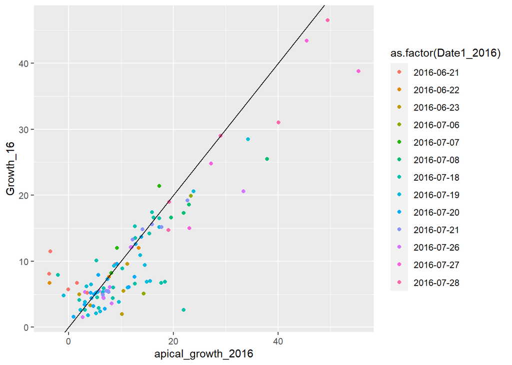

```r
ggplot(df_both_yrs, aes(x = apical_growth_2016, Growth_16, col = as.factor(Date1_2016)))+
  geom_point()+
  geom_abline(intercept = 0,slope = 1)
```

### Histogram of differences

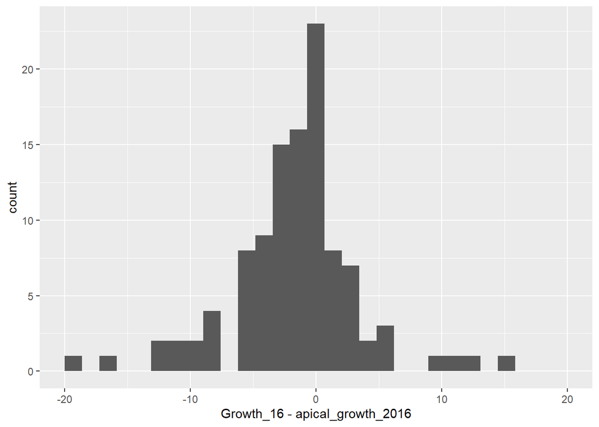

```r
ggplot(df_both_yrs)+
  geom_histogram(aes(x = Growth_16 - apical_growth_2016))+
  xlim(-20, 20)
```

### Count neg vs pos

```r
df_both_yrs %>%
  mutate(neg_growth = ifelse(Growth_16 - apical_growth_2016 < 0, 1, 0)) %>%
  group_by(neg_growth) %>%
  summarize(n())
```

```
## # A tibble: 2 x 2
##   neg_growth `n()`
##        <dbl> <int>
## 1          0    38
## 2          1    69
```

```r
df_both_yrs %>%
  summarize(mean(Growth_16 - apical_growth_2016))
```

```
## # A tibble: 1 x 1
##   `mean(Growth_16 - apical_growth_2016)`
##                                    <dbl>
## 1                                  -1.62
```

### Plot 2017 height as measured in 2017 against total height as measured in 2016, and check for a pattern with height

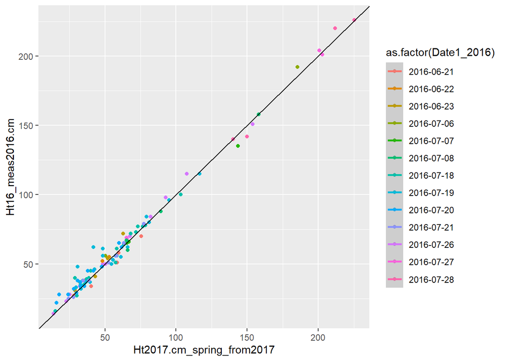

```r
ggplot(df_both_yrs, aes(x = Ht2017.cm_spring_from2017, y = Ht16_meas2016.cm, col = as.factor(Date1_2016)))+
  geom_point()+
  geom_abline(intercept = 0, slope = 1)+
  geom_smooth()
```

# Save these data up until now

```r
save(df, file = "../../compiled_data/fire_footprints/df_vert_wide.Rdata")
```

## Add 2015 heights measured in 2016 for trees still missing 2015 height

```r
df <- df %>%
  mutate(Ht2015.cm_spring = ifelse(is.na(Ht2015.cm_spring_from2017), Ht2015.meas2016, Ht2015.cm_spring_from2017))
```

### Check

```r
df %>%
  dplyr::select(Ht2017.cm.fall, Growth_17, Growth_16, Growth_15, Ht2015.cm_spring_from2017, Ht2015.meas2016, Ht2015.cm_spring) %>%
  arrange(desc(Ht2015.meas2016))
```

```
## # A tibble: 216 x 7
##    Ht2017.cm.fall Growth_17 Growth_16 Growth_15 Ht2015.cm_spring_from2017 Ht2015.meas2016 Ht2015.cm_spring
##             <dbl>     <dbl>     <dbl>     <dbl>                     <dbl>           <dbl>            <dbl>
##  1            199      13.5      19.9      11.6                      154              157             154
##  2            276      50.5      46.5      25.5                      154.             155             154.
##  3            238      26        31        24                        157              148             157
##  4             NA      NA        NA        NA                         NA              125             125
##  5            222      19.1      43.4      38.5                      121              120             121
##  6            165      15        19        11                        120              115             120
##  7            216      15.3      38.8      37                        125.             113             125.
##  8            167      13        20.6      14.8                      119.             105             119.
##  9            156      12.5      21.4      11.8                      110.             105             110.
## 10            115      NA        NA        10.1                       NA              104             104
## # ... with 206 more rows
```

### Count how many seedlings this applies to

```r
df %>%
  filter(is.na(Ht2015.cm_spring_from2017) & !is.na(Ht2015.meas2016)) %>%
  group_by(Species) %>%
  summarize(n())
```

```
## # A tibble: 2 x 2
##   Species `n()`
##   <chr>   <int>
## 1 ABCO       19
## 2 PIPO        3
```

### Find seedlings this didn’t work for

```r
df %>%
  filter(is.na(Ht2015.cm_spring)) %>%
  dplyr::select(Sdlg, FirePatch, LastYearGrth.cm, Ht16_meas2016.cm, Ht2017.cm.fall, Ht2015.meas2016, Growth_17, Growth_16, Growth_15, Ht2015.cm_spring)
```

```
## # A tibble: 22 x 10
##    Sdlg  FirePatch LastYearGrth.cm Ht16_meas2016.cm Ht2017.cm.fall Ht2015.meas2016 Growth_17 Growth_16 Growth_15 Ht2015.cm_spring
##    <chr> <chr>               <dbl>            <dbl>          <dbl>           <dbl>     <dbl>     <dbl>     <dbl>            <dbl>
##  1 72    AMRC-NW              3.94             23               25              NA       5.6       4.8        NA               NA
##  2 82    AMRC-2              11.8              42               NA              NA      NA        NA          NA               NA
##  3 84    AMRC-2               8.12             95               NA              NA      NA        NA          NA               NA
##  4 91    AMRC-2               3.96             20               NA              NA      NA        NA          NA               NA
##  5 92    AMRC-2               3.42             11               NA              NA      NA        NA          NA               NA
##  6 93    AMRC-2               2.27             18               NA              NA      NA        NA          NA               NA
##  7 106   AMRC-2              15.3              68               NA              NA      NA        NA          NA               NA
##  8 107   AMRC-2              15.2              46               NA              NA      NA        NA          NA               NA
##  9 123   WRTS-1               8                95               NA              NA      NA        NA          NA               NA
## 10 135   WRTS-1               2.48             18.2             NA              NA      NA        NA          NA               NA
## # ... with 12 more rows
```

### Count seedlings without 2017 height or 2015 height measured in 2016

```r
df %>%
  filter(is.na(Ht2017.cm.fall) & is.na(Ht2015.meas2016)) %>%
  group_by(Species) %>%
  summarize(n())
```

```
## # A tibble: 2 x 2
##   Species `n()`
##   <chr>   <int>
## 1 ABCO        8
## 2 PIPO       11
```

### List them

```r
df %>%
  filter(is.na(Ht2017.cm.fall) & is.na(Ht2015.meas2016)) %>%
  select(Sdlg, Species, FirePatch, Datasheet1_2016, Datasheet2_2016, Date1_2016, Date2_2016) %>%
  arrange(Date1_2016)
```

```
## # A tibble: 19 x 7
##    Sdlg  Species FirePatch Datasheet1_2016                   Datasheet2_2016 Date1_2016 Date2_2016
##    <chr> <chr>   <chr>     <chr>                             <chr>           <date>     <date>
##  1 20    PIPO    FRDS-JB   Data_Sheet_FRED_Jun10             NA              2016-06-10 9999-09-09
##  2 21    PIPO    FRDS-JB   Data_Sheet_FRED_Jun10             NA              2016-06-10 9999-09-09
##  3 22    PIPO    FRDS-JB   Data_Sheet_FRED_Jun10             NA              2016-06-10 9999-09-09
##  4 23    PIPO    FRDS-JB   Data_Sheet_FRED_Jun10             NA              2016-06-10 9999-09-09
##  5 82    ABCO    AMRC-2    Data_Sheet_AMCR_2_JUN23_2         NA              2016-06-23 9999-09-09
##  6 84    PIPO    AMRC-2    Data_Sheet_AMCR_2_JUN23_2         NA              2016-06-23 9999-09-09
##  7 91    ABCO    AMRC-2    Data_Sheet_AMCR_2_JUN23_2         NA              2016-06-23 9999-09-09
##  8 92    ABCO    AMRC-2    Data_Sheet_AMCR_2_JUN23_2         NA              2016-06-23 9999-09-09
##  9 93    ABCO    AMRC-2    Data_Sheet_AMCR_2_JUN23_2         NA              2016-06-23 9999-09-09
## 10 106   ABCO    AMRC-2    Data_Sheet_AMCR_2_JUN23_2         NA              2016-06-23 9999-09-09
## 11 107   ABCO    AMRC-2    Data_Sheet_AMCR_2_JUN23_2         NA              2016-06-23 9999-09-09
## 12 123   ABCO    WRTS-1    Data_Sheet_WRTS_1_JUN_29_4        NA              2016-06-29 9999-09-09
## 13 135   ABCO    WRTS-1    Data_Sheet_WRTS_1_JUN_29          NA              2016-06-29 9999-09-09
## 14 132   PIPO    FRDS-N    Data_Sheet_FRDS_N_JUN29           NA              2016-06-29 9999-09-09
## 15 145   PIPO    FRDS-SE   Data_Sheet_FRDS_SE_JUL_1          NA              2016-07-01 9999-09-09
## 16 147   PIPO    FRDS-SE   Data_Sheet_FRDS_SE_JUL_1          NA              2016-07-01 9999-09-09
## 17 148   PIPO    FRDS-SE   Data_Sheet_FRDS_SE_JUL_1          NA              2016-07-01 9999-09-09
## 18 155   PIPO    FRDS-SE   Data_Sheet_FRDS_SE_JUL_1          NA              2016-07-01 9999-09-09
## 19 176   PIPO    STAR-mid  Data_Sheet_STAR_MID_JUL_6_2016(1) NA              2016-07-06 9999-09-09
```

### For those seedlings, find 2015 growth by creating a regression model

### Find average 2016 growing season apical growth for the seedlings with data on it

```r
find_apical_growth <- df %>%
  filter(!is.na(Ht2015.meas2016)) %>%
  mutate(apical_growth_2016 =
           Ht16_meas2016.cm - LastYearGrth.cm - Ht2015.meas2016) %>%
  dplyr::select(Sdlg, Species, Ht16_meas2016.cm, LastYearGrth.cm, Ht2015.meas2016, apical_growth_2016, Date1_2016) %>%
  mutate(apical_ratio = apical_growth_2016/LastYearGrth.cm) %>%
  distinct()
find_apical_growth
```

```
## # A tibble: 126 x 8
##    Sdlg  Species Ht16_meas2016.cm LastYearGrth.cm Ht2015.meas2016 apical_growth_2016 Date1_2016 apical_ratio
##    <chr> <chr>              <dbl>           <dbl>           <dbl>              <dbl> <date>            <dbl>
##  1 6     ABCO                9.45            1.92               9              -1.47 2016-05-30       -0.766
##  2 275   ABCO               28               0.8               19               8.2  2016-07-26       10.2
##  3 276   ABCO               14               1.29              10               2.71 2016-07-26        2.10
##  4 277   PIPO               84               3.43              73               7.57 2016-07-26        2.21
##  5 278   PIPO               98               3.93              82              12.1  2016-07-26        3.07
##  6 279   PIPO              115              11.1               92              11.9  2016-07-26        1.07
##  7 280   PIPO               70               2.35              61               6.65 2016-07-26        2.83
##  8 281   ABCO               23               4.15              13               5.85 2016-07-26        1.41
##  9 282   ABCO               50               8.29              35               6.71 2016-07-26        0.809
## 10 283   ABCO               34               3.87              27               3.13 2016-07-26        0.809
## # ... with 116 more rows
```

### Check whether that ratio changes with height or date, excluding the very high values that seem like mistakes

#### Reformat data for LM

```r
df <- df %>%
  mutate(Species = as.factor(Species))
test <- find_apical_growth %>%
  mutate(Date1_2016 = as.numeric(Date1_2016)) %>%
  mutate(Species = as.factor(Species))
```

#### Model growth based on species, date, and last year of growth

```r
lm <- lm(apical_growth_2016 ~ Date1_2016 + Species*LastYearGrth.cm, data = test)
summary(lm)
```

```
##
## Call:
## lm(formula = apical_growth_2016 ~ Date1_2016 + Species * LastYearGrth.cm,
##     data = test)
##
## Residuals:
##      Min       1Q   Median       3Q      Max
## -16.0641  -3.7696  -0.0615   3.3563  16.3384
##
## Coefficients:
##                               Estimate Std. Error t value Pr(>|t|)
## (Intercept)                 -2.389e+03  7.390e+02  -3.233  0.00158 **
## Date1_2016                   1.409e-01  4.349e-02   3.239  0.00155 **
## SpeciesPIPO                 -5.610e-01  1.931e+00  -0.290  0.77194
## LastYearGrth.cm              5.254e-01  1.297e-01   4.051 9.04e-05 ***
## SpeciesPIPO:LastYearGrth.cm  7.324e-01  1.658e-01   4.418 2.18e-05 ***
## ---
## Signif. codes:  0 '***' 0.001 '**' 0.01 '*' 0.05 '.' 0.1 ' ' 1
##
## Residual standard error: 5.715 on 121 degrees of freedom
## Multiple R-squared:  0.719,  Adjusted R-squared:  0.7097
## F-statistic: 77.41 on 4 and 121 DF,  p-value: < 2.2e-16
```

```r
drop1(lm, test= "Chisq")
```

```
## Single term deletions
##
## Model:
## apical_growth_2016 ~ Date1_2016 + Species * LastYearGrth.cm
##                         Df Sum of Sq    RSS    AIC  Pr(>Chi)
## <none>                               3951.5 444.14
## Date1_2016               1    342.62 4294.1 452.62  0.001209 **
## Species:LastYearGrth.cm  1    637.51 4589.0 460.99 1.417e-05 ***
## ---
## Signif. codes:  0 '***' 0.001 '**' 0.01 '*' 0.05 '.' 0.1 ' ' 1
```

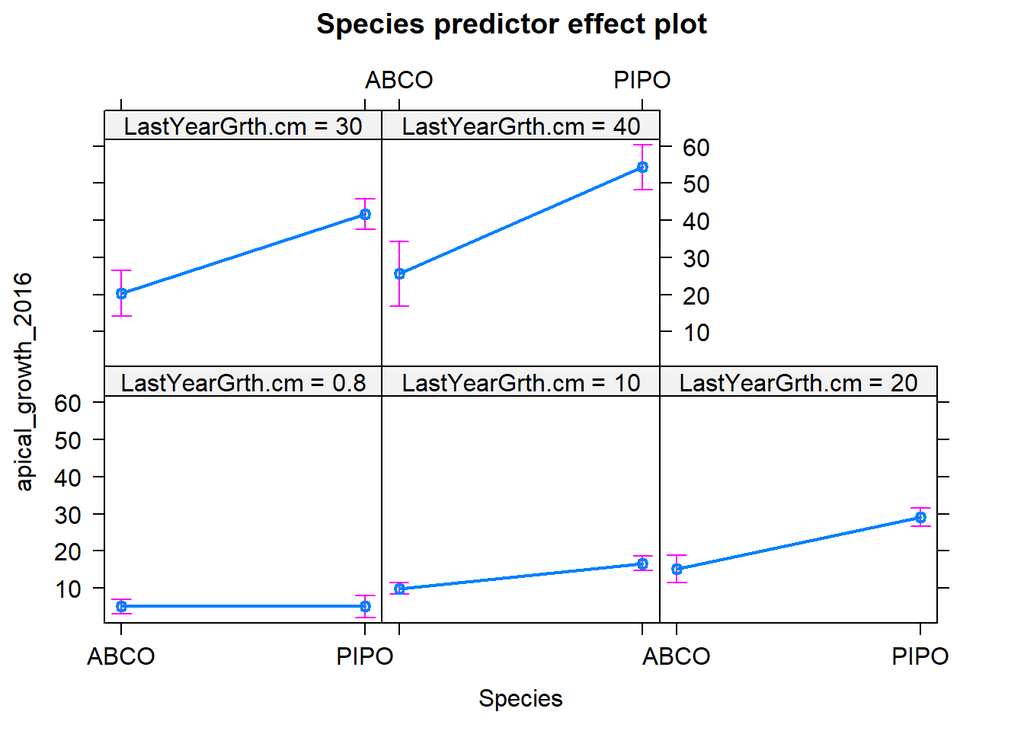

```r
plot(predictorEffect("Species", lm))
```

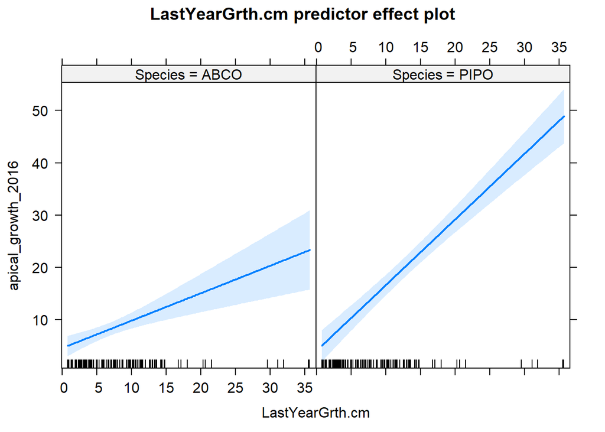

```r
plot(predictorEffect("LastYearGrth.cm", lm))
```

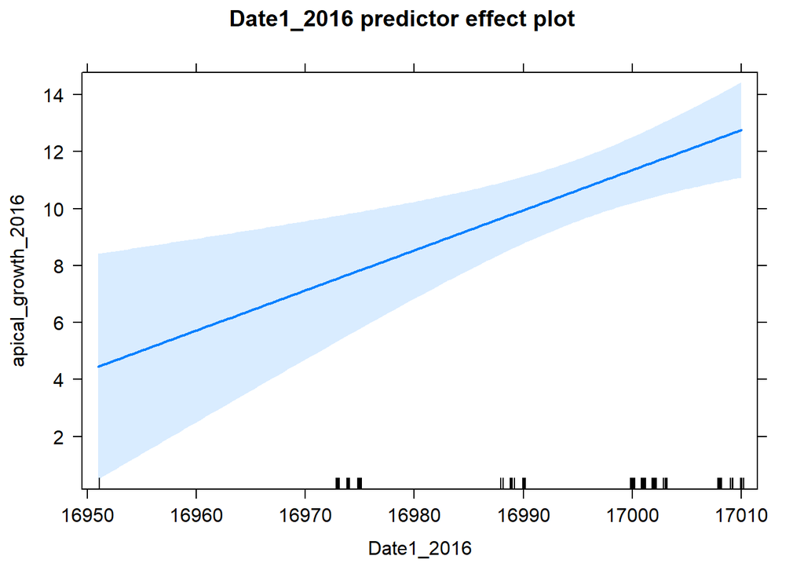

```r
plot(predictorEffect("Date1_2016", lm))
```

### Look at seedlings who have a weirdly high ratio

```r
find_apical_growth %>%
  filter(apical_ratio>5)
```

```
## # A tibble: 5 x 8
##   Sdlg  Species Ht16_meas2016.cm LastYearGrth.cm Ht2015.meas2016 apical_growth_2016 Date1_2016 apical_ratio
##   <chr> <chr>              <dbl>           <dbl>           <dbl>              <dbl> <date>            <dbl>
## 1 275   ABCO                  28            0.8               19               8.2  2016-07-26        10.2
## 2 229   ABCO                  42            0.85              34               7.15 2016-07-19         8.41
## 3 250   ABCO                  38            1.45              24              12.5  2016-07-20         8.66
## 4 255   ABCO                  38            1.37              29               7.63 2016-07-21         5.57
## 5 264   ABCO                  51            3.27              30              17.7  2016-07-21         5.42
```

### Find predicted growth for each seedling based on the linear model above

```r
df$apical_growth_pred <- predict(lm, newdata = df %>% mutate(Date1_2016 = as.numeric(Date1_2016)))
```

### Then use this value for the seedlings that don’t have 2015 height recorded

```r
df <- df %>%
   mutate(Ht2015.calc2016 =
           ifelse(is.na(Ht2017.cm.fall) &
                    is.na(Ht2015.meas2016),
                  Ht16_meas2016.cm - LastYearGrth.cm - apical_growth_pred,
                  Ht2015.meas2016))

df %>%
  filter(is.na(Ht2017.cm.fall)) %>%
  dplyr::select(Sdlg, Ht16_meas2016.cm, LastYearGrth.cm, Ht2015.meas2016, Ht2015.calc2016)
```

```
## # A tibble: 32 x 5
##    Sdlg  Ht16_meas2016.cm LastYearGrth.cm Ht2015.meas2016 Ht2015.calc2016
##    <chr>            <dbl>           <dbl>           <dbl>           <dbl>
##  1 58                  30            3.03              25            25
##  2 80                  49            3.93              31            31
##  3 81                  57           11.4               54            54
##  4 82                  42           11.8               NA            22.3
##  5 83                  58            4                 40            40
##  6 84                  95            8.12              NA            75.5
##  7 85                  68            5.86              60            60
##  8 86                  45            3.57              33            33
##  9 87                  72           10.7               61            61
## 10 88                  47           12.6               28            28
## # ... with 22 more rows
```

## Assign 2015 spring height as Ht2015 calculated in 2016 if there’s no 2017 value

```r
df <- df %>%
  mutate(Ht2015.cm_spring = ifelse(is.na(Ht2015.cm_spring), Ht2015.calc2016, Ht2015.cm_spring))
```

## Find seedlings STILL missing 2015 height

```r
df %>%
  filter(is.na(Ht2015.cm_spring)) %>%
  dplyr::select(Sdlg, LastYearGrth.cm, Ht16_meas2016.cm, Ht2017.cm.fall, Ht2015.meas2016, Growth_17, Growth_16, Growth_15, Note1_2016, Note2_2016, Notes2017)
```

```
## # A tibble: 3 x 11
##   Sdlg  LastYearGrth.cm Ht16_meas2016.cm Ht2017.cm.fall Ht2015.meas2016 Growth_17 Growth_16 Growth_15 Note1_2016 Note2_2016 Notes2017
##   <chr>           <dbl>            <dbl>          <dbl>           <dbl>     <dbl>     <dbl>     <dbl> <chr>      <chr>      <chr>
## 1 72               3.94               23             25              NA       5.6       4.8      NA   ""         ""         leader died in 2015, s~
## 2 131             13.2                68             60              NA      NA        NA        13   ""         ""         leader broke off; 2017~
## 3 161             11.8                81             76              NA      NA        15.5      12.8 ""         ""         deets in CT notebook
```

## Add height for those special cases

```r
df <- df %>%
  mutate(Ht2015.cm_spring = ifelse(Sdlg == 6, Ht2017.cm.fall-Growth_15, Ht2015.cm_spring)) %>%
  mutate(Ht2015.cm_spring = ifelse(Sdlg == 72, Ht2017.cm.fall-Growth_17 - Growth_16, Ht2015.cm_spring)) %>%
  mutate(Ht2015.cm_spring = ifelse(Sdlg == 131, Ht2017.cm.fall-Growth_15, Ht2015.cm_spring)) %>%
  mutate(Ht2015.cm_spring = ifelse(Sdlg == 161, Ht2017.cm.fall-Growth_15 - Growth_16, Ht2015.cm_spring))
```

# Add columns for 2016 and 2017 spring heights

```r
df <- df %>%
  mutate(Ht2017.cm_spring = Ht2017.cm.fall - Growth_17) %>%
  mutate(Ht2016.cm_spring = Ht2017.cm.fall - Growth_17 - Growth_16)
```

# Look at odd seedlings

```r
df %>%
  filter(Sdlg %in% c(75, 161)) %>%
  dplyr::select(Sdlg, LastYearGrth.cm, Ht16_meas2016.cm, Ht2017.cm.fall, Ht2015.meas2016, Growth_17, Growth_16, Growth_15, Note1_2016, Note2_2016, Notes2017, Ht2016.cm_spring, Ht2017.cm_spring, Ht2015.cm_spring)
```

```
## # A tibble: 2 x 14
##   Sdlg  LastYearGrth.cm Ht16_meas2016.cm Ht2017.cm.fall Ht2015.meas2016 Growth_17 Growth_16 Growth_15 Note1_2016 Note2_2016 Notes2017
##   <chr>           <dbl>            <dbl>          <dbl>           <dbl>     <dbl>     <dbl>     <dbl> <chr>      <chr>      <chr>
## 1 75               7.65               49             48              45        NA       6.7       8.1 "same shr~ ""         2017 gro~
## 2 161             11.8                81             76              NA        NA      15.5      12.8 ""         ""         deets in~
## # ... with 3 more variables: Ht2016.cm_spring <dbl>, Ht2017.cm_spring <dbl>, Ht2015.cm_spring <dbl>
```

## Fix them

```r
df <- df %>%
  mutate(Ht2016.cm_spring = ifelse(Sdlg == 75, Ht2017.cm.fall - Growth_16, Ht2016.cm_spring)) %>%
  mutate(Ht2015.cm_spring = ifelse(Sdlg == 75, Ht2017.cm.fall - Growth_16 - Growth_15, Ht2015.cm_spring)) %>%
  mutate(Ht2016.cm_spring = ifelse(Sdlg == 161, Ht2017.cm.fall - Growth_16, Ht2016.cm_spring))
```

# Create data frame with one row per growth measurement

```r
df <- tbl_df(df)
df <- df %>%
  rename(`2017` = Growth_17, `2016` = Growth_16, `2015` = Growth_15)
df <- gather(df, "Year", "VertGrowth_cm",c(`2017`, `2016`, `2015`))
df$Year <- as.factor(df$Year)
```

## Check

```r
df %>% dplyr::select(Sdlg, Year, VertGrowth_cm)
```

```
## # A tibble: 648 x 3
##    Sdlg  Year  VertGrowth_cm
##    <chr> <fct>         <dbl>
##  1 2     2017           14.5
##  2 4     2017            3.2
##  3 5     2017           12.5
##  4 6     2017           NA
##  5 8     2017           11.5
##  6 9     2017           11.5
##  7 10    2017           14
##  8 11    2017            1.8
##  9 12    2017           17.2
## 10 13    2017            0.6
## # ... with 638 more rows
```

```r
summary(df$Year)
```

```
## 2015 2016 2017
##  216  216  216
```

# Remove bad rows

## Take out 2017 vertical growth measurements for trees that died since last measure

```r
summary(as.factor(df$Status))
```

```
##  Actually PILA          alive could not find           dead           done           DONE          eaten      herbicide     herbicided
##              3             63              6             21             81            390              3              9             18
##      not found         unsure
##             51              3
```

```r
df <- df %>%
  filter(!(Status %in% c("DEAD", "dead") & Year == "2017"))
```

## Take out 2016 and 2017 vertical growth measurements for trees that were not found

```r
df <- df %>%
  filter(!(Status %in% c("could not find","not found", "eaten", "herbicide","herbicided") & Year %in% c("2016", "2017")))
```

## Check out NA values and delete years that broke off

```r
df %>%
  filter(is.na(VertGrowth_cm)) %>%
  dplyr::select(Sdlg, Year, VertGrowth_cm, Status,  Note1_2016, Note2_2016, Notes2017) %>%
  arrange(Sdlg)
```

```
## # A tibble: 54 x 7
##    Sdlg  Year  VertGrowth_cm Status     Note1_2016                                            Note2_2016     Notes2017
##    <chr> <fct>         <dbl> <chr>      <chr>                                                 <chr>          <chr>
##  1 100   2015             NA not found  ""                                                    ""             <NA>
##  2 103   2015             NA not found  ""                                                    ""             <NA>
##  3 106   2015             NA not found  ""                                                    "mastication ~ <NA>
##  4 107   2015             NA not found  ""                                                    "mastication ~ <NA>
##  5 123   2015             NA could not~ "slope and aspect from Data_Sheet_WRTS_1_JUN_29; Las~ ""             <NA>
##  6 131   2017             NA DONE       ""                                                    ""             leader broke off; 2017 and 2016 growt~
##  7 131   2016             NA DONE       ""                                                    ""             leader broke off; 2017 and 2016 growt~
##  8 132   2017             NA Actually ~ ""                                                    ""             <NA>
##  9 132   2016             NA Actually ~ ""                                                    ""             <NA>
## 10 132   2015             NA Actually ~ ""                                                    ""             <NA>
## # ... with 44 more rows
```

```r
df <- df %>%
  filter(!(Sdlg %in% c("6","185","131","226","6","74","98", "132") & Year %in% c("2017","2016"))) %>%
  filter(!(Sdlg %in% c(145, 195,78) & Year == "2016")) %>%
  filter(!(Sdlg == 75 & Year == 2017))
```

## Use growth measured in 2016 (which was 2015 growth) if 2015 growth couldn’t be measured in 2017

```r
df <- df %>%
  mutate(VertGrowth_cm = ifelse(is.na(VertGrowth_cm) & Year == "2015", LastYearGrth.cm, VertGrowth_cm))
```

## Look at odd vertical growth value

```r
df %>%
  filter(Sdlg == "195") %>%
  dplyr::select(Sdlg, Year, LastYearGrth.cm, VertGrowth_cm, Ht16_meas2016.cm, Ht2017.cm.fall, Ht2015.meas2016)
```

```
## # A tibble: 1 x 7
##   Sdlg  Year  LastYearGrth.cm VertGrowth_cm Ht16_meas2016.cm Ht2017.cm.fall Ht2015.meas2016
##   <chr> <fct>           <dbl>         <dbl>            <dbl>          <dbl>           <dbl>
## 1 195   2015             20.3          20.3              182             NA             125
```

### Replace its 2015 growth with LastYearGrowth measured in 2016

```r
df <- df %>%
  mutate(VertGrowth_cm = ifelse(Sdlg == "195" & Year == "2015", LastYearGrth.cm, VertGrowth_cm))
```

# Make VertGrowth numeric

```r
df$VertGrowth_cm <- as.numeric(df$VertGrowth_cm)
```

# Add height column that changes depending on year that represents height BEFORE that year’s growth

```r
df <- df %>%
  mutate(Ht_cm = ifelse(Year == "2017", Ht2017.cm_spring,
                        ifelse(Year == "2016", Ht2016.cm_spring,
                               ifelse(Year == "2015", Ht2015.cm_spring, 0))))
```

## Find missing heights

```r
df %>%
  filter(is.na(Ht_cm)) %>%
  dplyr::select(Sdlg, LastYearGrth.cm, Ht2016.cm_spring, Ht2017.cm.fall, Ht2015.meas2016, Year, VertGrowth_cm,  Note1_2016, Note2_2016, Notes2017)
```

```
## # A tibble: 0 x 10
## # ... with 10 variables: Sdlg <chr>, LastYearGrth.cm <dbl>, Ht2016.cm_spring <dbl>, Ht2017.cm.fall <dbl>, Ht2015.meas2016 <dbl>, Year <fct>,
## #   VertGrowth_cm <dbl>, Note1_2016 <chr>, Note2_2016 <chr>, Notes2017 <chr>
```

# Change years since fire depending on year of growth

```r
df %>%
  group_by(Fire, Year, Years) %>%
  summarize(n())
```

```
## # A tibble: 15 x 4
## # Groups:   Fire, Year [15]
##    Fire  Year  Years `n()`
##    <chr> <fct> <dbl> <int>
##  1 AMRC  2015      8   122
##  2 AMRC  2016      8    99
##  3 AMRC  2017      8    95
##  4 CLVD  2015     24    25
##  5 CLVD  2016     24    24
##  6 CLVD  2017     24    24
##  7 FRDS  2015     12    36
##  8 FRDS  2016     12    25
##  9 FRDS  2017     12    25
## 10 STAR  2015     14    19
## 11 STAR  2016     14    17
## 12 STAR  2017     14    16
## 13 WRTS  2015     35    14
## 14 WRTS  2016     35    12
## 15 WRTS  2017     35    12
```

```r
df <- df %>%
  mutate(FireYear = ifelse(Fire == "AMRC", 2008, ifelse(Fire == "CLVD", 1992, ifelse(Fire == "FRDS", 2004, ifelse(Fire == "STAR", 2001, 1981))))) %>%
  mutate(Years = as.numeric(paste(Year))-FireYear)
```

## Check

```r
df %>%
  group_by(Fire, FireYear, Year, Years) %>%
  summarize(n())
```

```
## # A tibble: 15 x 5
## # Groups:   Fire, FireYear, Year [15]
##    Fire  FireYear Year  Years `n()`
##    <chr>    <dbl> <fct> <dbl> <int>
##  1 AMRC      2008 2015      7   122
##  2 AMRC      2008 2016      8    99
##  3 AMRC      2008 2017      9    95
##  4 CLVD      1992 2015     23    25
##  5 CLVD      1992 2016     24    24
##  6 CLVD      1992 2017     25    24
##  7 FRDS      2004 2015     11    36
##  8 FRDS      2004 2016     12    25
##  9 FRDS      2004 2017     13    25
## 10 STAR      2001 2015     14    19
## 11 STAR      2001 2016     15    17
## 12 STAR      2001 2017     16    16
## 13 WRTS      1981 2015     34    14
## 14 WRTS      1981 2016     35    12
## 15 WRTS      1981 2017     36    12
```

# Calculate relative vertical growth

```r
df %>% dplyr::select(Sdlg, Year, Ht_cm, VertGrowth_cm) %>% arrange(Sdlg)
```

```
## # A tibble: 565 x 4
##    Sdlg  Year  Ht_cm VertGrowth_cm
##    <chr> <fct> <dbl>         <dbl>
##  1 10    2017  171            14
##  2 10    2016  146            25
##  3 10    2015  123.           23.3
##  4 100   2015   75            20.6
##  5 103   2015   50            29.6
##  6 104   2017   66.1           3.9
##  7 104   2016   52.6          13.5
##  8 104   2015   41.8          10.8
##  9 105   2017   26.3           5.7
## 10 105   2016   24.2           2.1
## # ... with 555 more rows
```

```r
df <- df %>%
  rename(Ht_cm1 = Ht_cm) %>%
  mutate(Ht_cm2 = Ht_cm1+VertGrowth_cm) %>%
  #mutate(VertGrowth_Rel = log(Ht_cm2) - log(Ht_cm1))
  mutate(VertGrowth_Rel = (Ht_cm2 - Ht_cm1)/Ht_cm1) %>%
  mutate(VertGrowth_Rel = log(VertGrowth_Rel))
df %>% dplyr::select(Sdlg, Year, Ht_cm1, Ht_cm2, VertGrowth_cm, VertGrowth_Rel) %>% arrange(Sdlg)
```

```
## # A tibble: 565 x 6
##    Sdlg  Year  Ht_cm1 Ht_cm2 VertGrowth_cm VertGrowth_Rel
##    <chr> <fct>  <dbl>  <dbl>         <dbl>          <dbl>
##  1 10    2017   171    185            14           -2.50
##  2 10    2016   146    171            25           -1.76
##  3 10    2015   123.   146            23.3         -1.66
##  4 100   2015    75     95.6          20.6         -1.29
##  5 103   2015    50     79.6          29.6         -0.525
##  6 104   2017    66.1   70             3.9         -2.83
##  7 104   2016    52.6   66.1          13.5         -1.36
##  8 104   2015    41.8   52.6          10.8         -1.35
##  9 105   2017    26.3   32             5.7         -1.53
## 10 105   2016    24.2   26.3           2.1         -2.44
## # ... with 555 more rows
```

## Find NAs

```r
df %>%
  filter(is.na(VertGrowth_cm) | is.na(VertGrowth_Rel))
```

```
## # A tibble: 0 x 81
## # ... with 81 variables: Sdlg <chr>, Species <fct>, Fire <chr>, FirePatch <chr>, Ht16_meas2016.cm <dbl>, Ht2017.cm.fall <dbl>, Patch <chr>,
## #   Elevation <dbl>, Nearby_Easting <dbl>, Nearby_Northing <dbl>, Slope.Deg <dbl>, Aspect.deg <dbl>, BasDia2016.cm <dbl>, LastYearGrth.cm <dbl>,
## #   HTLCB <dbl>, Dia_at_2016_growth <dbl>, Dia_at_2015_growth <dbl>, Ht2015.meas2016 <dbl>, Note1_2016 <chr>, Note2_2016 <chr>, Note3_Light <chr>,
## #   Datasheet1_2016 <chr>, Light_File <dbl>, DIFN <dbl>, return <chr>, Date1_2016 <date>, Date2_2016 <date>, personel2 <chr>, personel1 <chr>,
## #   Time1 <time>, Time2 <time>, Photo <chr>, Datasheet2_2016 <chr>, ShrubSpp03 <chr>, Cov1 <dbl>, Ht1 <dbl>, Cov1.2 <dbl>, Ht1.2 <dbl>,
## #   Cov1.3 <dbl>, Ht1.3 <dbl>, DIFN.all <dbl>, ref <dbl>, Date <chr>, LAI.53 <dbl>, DIFN.53 <dbl>, Years <dbl>, Date2017 <dbl>,
## #   DataSheet2017 <chr>, Map <chr>, Status <chr>, BasDia2017.mm.1 <chr>, BasDia2017.mm.2 <chr>, Notes2017 <chr>, shrubarea3 <dbl>,
## #   shrubarea2 <dbl>, shrubarea1 <dbl>, siteclass <dbl>, Y <dbl>, X <dbl>, file_lat <chr>, Aspect.rad <dbl>, Slope.rad <dbl>, Lat.rad <dbl>,
## #   Aspect.rad.fold.NS <dbl>, Aspect.rad.fold.NESW <dbl>, incidrad <dbl>, heatload <dbl>, Ht2015.cm_spring_from2017 <dbl>,
## #   Ht2016.cm_spring_from2017 <dbl>, Ht2017.cm_spring_from2017 <dbl>, Ht2015.cm_spring <dbl>, apical_growth_pred <dbl>, Ht2015.calc2016 <dbl>,
## #   Ht2017.cm_spring <dbl>, Ht2016.cm_spring <dbl>, Year <fct>, VertGrowth_cm <dbl>, Ht_cm1 <dbl>, FireYear <dbl>, Ht_cm2 <dbl>,
## #   VertGrowth_Rel <dbl>
```

# Consolidate shrub species into fewer categories

## List all shrubs now

```r
summary(as.factor(df$ShrubSpp03))
```

```
##   ARPA   CECO   CEIN   CEPR   CHFO   CHSE   LIDE  other   PREM   QUVA willow   NA's
##    128    258     43     12     40     27     27      1     13     10      4      2
```

```r
df %>%
  group_by(Species, ShrubSpp03) %>%
  summarize(count = n()) %>%
  arrange(desc(count)) %>%
  filter(Species == "ABCO") %>%
  ungroup() %>%
  mutate(percent = count/sum(count))
```

```
## # A tibble: 9 x 4
##   Species ShrubSpp03 count percent
##   <fct>   <chr>      <int>   <dbl>
## 1 ABCO    CECO         194 0.618
## 2 ABCO    ARPA          57 0.182
## 3 ABCO    CHSE          26 0.0828
## 4 ABCO    CEPR          12 0.0382
## 5 ABCO    PREM           9 0.0287
## 6 ABCO    CEIN           6 0.0191
## 7 ABCO    willow         4 0.0127
## 8 ABCO    LIDE           3 0.00955
## 9 ABCO    QUVA           3 0.00955
```

Pick the species with 5. For ABCO, the winning set is CECO, ARPA, CHSE, CEPR, PREM, and CEIN.

```r
df %>%
  group_by(Species, ShrubSpp03) %>%
  summarize(count = n()) %>%
  arrange(desc(count)) %>%
  filter(Species == "PIPO") %>%
  ungroup() %>%
  mutate(percent = count/sum(count))
```

```
## # A tibble: 10 x 4
##    Species ShrubSpp03 count percent
##    <fct>   <chr>      <int>   <dbl>
##  1 PIPO    ARPA          71 0.283
##  2 PIPO    CECO          64 0.255
##  3 PIPO    CHFO          40 0.159
##  4 PIPO    CEIN          37 0.147
##  5 PIPO    LIDE          24 0.0956
##  6 PIPO    QUVA           7 0.0279
##  7 PIPO    PREM           4 0.0159
##  8 PIPO    <NA>           2 0.00797
##  9 PIPO    CHSE           1 0.00398
## 10 PIPO    other          1 0.00398
```

For PIPO, the winning set is CECO, ARPA, CHFO, CEIN, LIDE

```r
df <- df %>%
  mutate(ShrubSpp03 = ifelse(Species == "ABCO" & !ShrubSpp03 %in% c("CECO", "ARPA", "CHSE", "CEPR", "PREM", "CEIN"), "Other", as.character(ShrubSpp03)))
```

```r
df <- df %>%
  mutate(ShrubSpp03 = ifelse(Species == "PIPO" & !ShrubSpp03 %in% c("CECO", "ARPA", "CHFO", "LIDE", "CEIN"), "Other", as.character(ShrubSpp03)))
```

## Make them factors

```r
df <- df %>%
  mutate(ShrubSpp03 = as.factor(ShrubSpp03))
```

## plot shrub cover growth by shrub species

```r
df_shrubs <- df %>%
  mutate(Years = as.factor(Years)) %>%
  group_by(ShrubSpp03, Years) %>%
  summarize(shrub_cover = mean(Cov1.3))
```

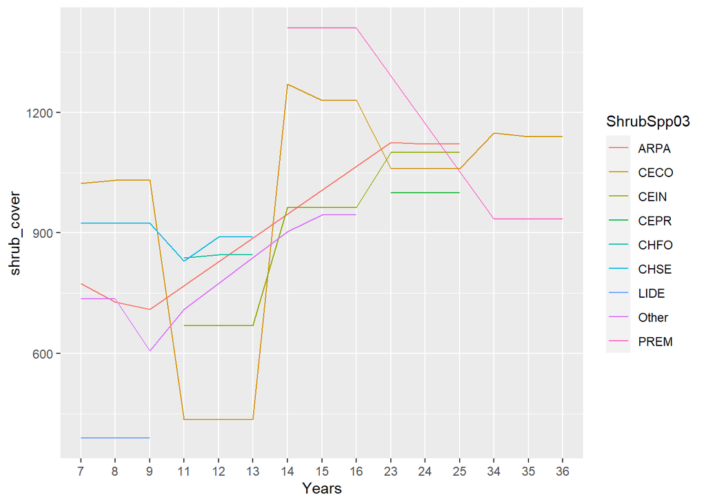

```r
ggplot(df_shrubs)+
  geom_line(aes(x = Years, y = shrub_cover, group=ShrubSpp03, col = ShrubSpp03))
```

## plot shrub cover growth overall

```r
df_shrubs <- df %>%
  group_by(Fire, Cov1.3, Ht1.3) %>%
  summarise(Years = mean(Years))
```

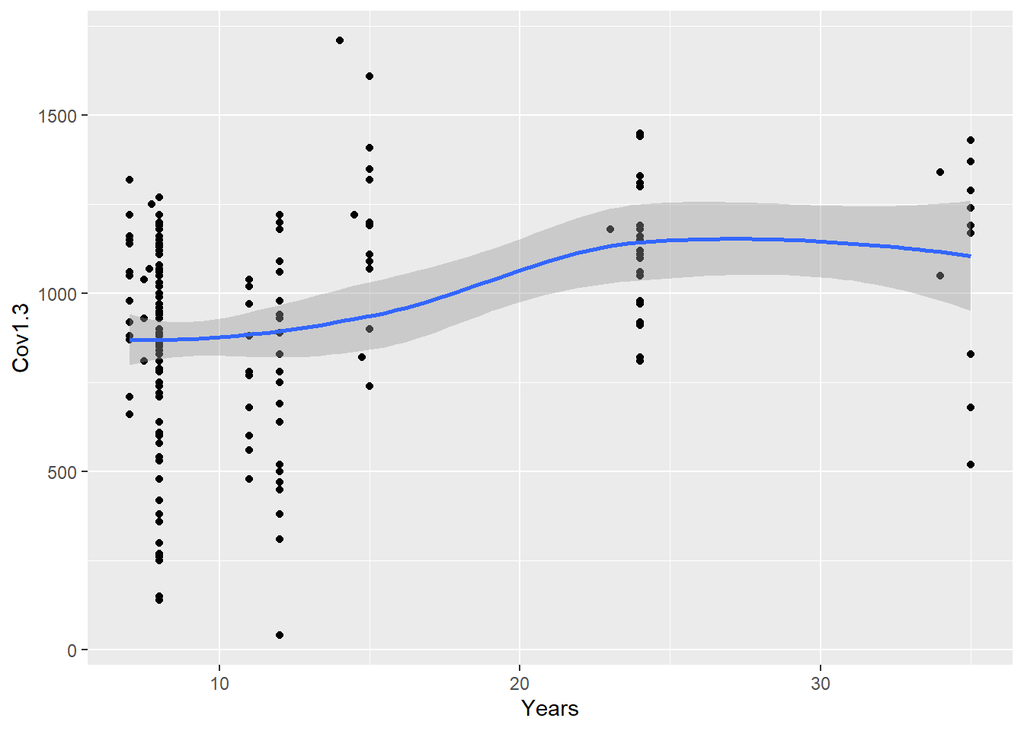

```r
ggplot(df_shrubs, aes(x = Years, y = Cov1.3))+
  geom_point()+
  stat_smooth(method = "loess", span = 1)
```

## plot shrub HEIGHT growth overall

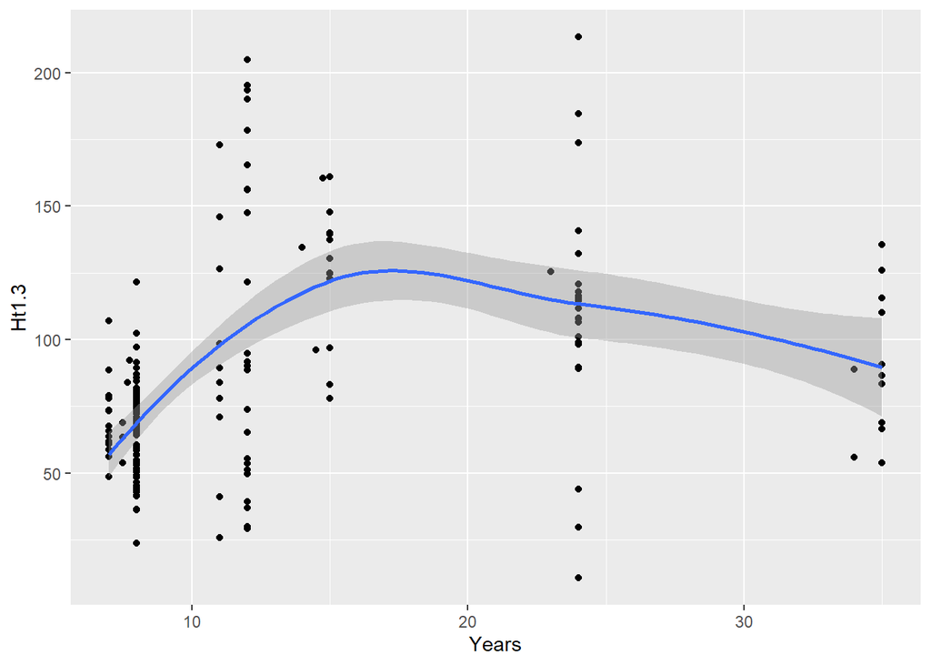

```r
ggplot(df_shrubs, aes(x = Years, y = Ht1.3))+
  geom_point()+
  stat_smooth(method = "loess", span = 1)
```

# Summarize shrub cover and height

```r
perc <- function(x){x/1200}
df %>%
  summarize(mincov = min(Cov1.3), medcov = median(Cov1.3), meancov = mean(Cov1.3),maxcov = max(Cov1.3)) %>%
  mutate_all(perc)
```

```
## # A tibble: 1 x 4
##   mincov medcov meancov maxcov
##    <dbl>  <dbl>   <dbl>  <dbl>
## 1 0.0333  0.817   0.780   1.42
```

```r
df %>%
  summarize(min(Ht1.3), median(Ht1.3), mean(Ht1.3), max(Ht1.3))
```

```
## # A tibble: 1 x 4
##   `min(Ht1.3)` `median(Ht1.3)` `mean(Ht1.3)` `max(Ht1.3)`
##          <dbl>           <dbl>         <dbl>        <dbl>
## 1         10.6            77.0          85.0         213.
```

# Drop extra levels

```r
df <- droplevels(df)
```

# Count by species

```r
df %>%
  dplyr::select(Species, Sdlg) %>%
  distinct() %>%
  group_by(Species) %>%
  summarize(n())
```

```
## # A tibble: 2 x 2
##   Species `n()`
##   <fct>   <int>
## 1 ABCO      123
## 2 PIPO       93
```

# Check for seedlings with too many years or repeat years

```r
repeats <- df %>%
  group_by(Sdlg) %>%
  summarize(n = n()) %>%
  filter(n >3)
df_reps <- df %>%
  filter(Sdlg %in% repeats$Sdlg)
df %>%
  group_by(Sdlg, Species, Year) %>%
  filter(n()>1) %>%
  arrange(desc(Species))
```

```
## # A tibble: 0 x 81
## # Groups:   Sdlg, Species, Year [0]
## # ... with 81 variables: Sdlg <chr>, Species <fct>, Fire <chr>, FirePatch <chr>, Ht16_meas2016.cm <dbl>, Ht2017.cm.fall <dbl>, Patch <chr>,
## #   Elevation <dbl>, Nearby_Easting <dbl>, Nearby_Northing <dbl>, Slope.Deg <dbl>, Aspect.deg <dbl>, BasDia2016.cm <dbl>, LastYearGrth.cm <dbl>,
## #   HTLCB <dbl>, Dia_at_2016_growth <dbl>, Dia_at_2015_growth <dbl>, Ht2015.meas2016 <dbl>, Note1_2016 <chr>, Note2_2016 <chr>, Note3_Light <chr>,
## #   Datasheet1_2016 <chr>, Light_File <dbl>, DIFN <dbl>, return <chr>, Date1_2016 <date>, Date2_2016 <date>, personel2 <chr>, personel1 <chr>,
## #   Time1 <time>, Time2 <time>, Photo <chr>, Datasheet2_2016 <chr>, ShrubSpp03 <fct>, Cov1 <dbl>, Ht1 <dbl>, Cov1.2 <dbl>, Ht1.2 <dbl>,
## #   Cov1.3 <dbl>, Ht1.3 <dbl>, DIFN.all <dbl>, ref <dbl>, Date <chr>, LAI.53 <dbl>, DIFN.53 <dbl>, Years <dbl>, Date2017 <dbl>,
## #   DataSheet2017 <chr>, Map <chr>, Status <chr>, BasDia2017.mm.1 <chr>, BasDia2017.mm.2 <chr>, Notes2017 <chr>, shrubarea3 <dbl>,
## #   shrubarea2 <dbl>, shrubarea1 <dbl>, siteclass <dbl>, Y <dbl>, X <dbl>, file_lat <chr>, Aspect.rad <dbl>, Slope.rad <dbl>, Lat.rad <dbl>,
## #   Aspect.rad.fold.NS <dbl>, Aspect.rad.fold.NESW <dbl>, incidrad <dbl>, heatload <dbl>, Ht2015.cm_spring_from2017 <dbl>,
## #   Ht2016.cm_spring_from2017 <dbl>, Ht2017.cm_spring_from2017 <dbl>, Ht2015.cm_spring <dbl>, apical_growth_pred <dbl>, Ht2015.calc2016 <dbl>,
## #   Ht2017.cm_spring <dbl>, Ht2016.cm_spring <dbl>, Year <fct>, VertGrowth_cm <dbl>, Ht_cm1 <dbl>, FireYear <dbl>, Ht_cm2 <dbl>,
## #   VertGrowth_Rel <dbl>
```

```r
boo <- (function(x) x[sapply(x, nrow)>0])(lapply(lapply(df_reps, function(x) tapply(x, df_reps$Sdlg, function(x) x[1]!=x[2])), function(x) subset(df_reps, Sdlg %in% names(which(x)))))
print(boo)
```

```
## named list()
```

# Change species and site class to factors

```r
df <- df %>%
  mutate(Species = as.factor(Species)) %>%
  mutate(Sdlg = as.factor(Sdlg), siteclass= as.factor(siteclass))
df <- droplevels(df)
```

# Convert shrub area to sqrt

```r
df <- df %>%
  mutate(sqrt_shrubarea3 = sqrt(shrubarea3)) %>%
  mutate(sqrt_shrubarea2 = sqrt(shrubarea2)) %>%
  mutate(sqrt_shrubarea1 = sqrt(shrubarea1))
```

# Take out seedling/year combos with 0 growth

```r
df <- df %>%
  filter(VertGrowth_cm!=0)
```

# Save df

```r
save(df, file = "../../compiled_data/fire_footprints/master_seedlings_vert.Rdata")
write.csv(df, file = "../../compiled_data/fire_footprints/master_seedlings_vert.csv", row.names = F)
```

# Print final seedlings

```r
sort(df$Sdlg)
```

```
##   [1] 10   10   10   100  103  104  104  104  105  105  105  106  107  108  108  108  109  109  109  11   11   11   110  110  110  112  112  112
##  [29] 113  113  113  115  115  115  116  116  116  117  117  117  118  118  118  119  119  119  12   12   12   120  120  120  121  121  121  122
##  [57] 122  122  123  124  124  124  125W 125W 125W 129  129  129  13   13   13   131  132  133  133  133  135  140  140  140  141  141  141  142
##  [85] 142  142  143  143  143  144  144  144  145  147  148  149  149  149  15   15   15   150  150  150  153  153  153  155  159  159  159  161
## [113] 161  162  162  162  163  163  163  164  164  164  166  166  166  167  167  167  168  168  168  169  169  169  170  170  170  171  171  171
## [141] 172  172  176  179  179  179  180  180  180  182  182  182  185  186  186  186  189  189  189  194  194  194  195  196  196  196  197  197
## [169] 197  198  198  198  2    2    2    20   202  202  202  203  203  203  204  204  204  205  205  205  206  206  206  207  207  207  208  208
## [197] 209  209  209  21   210  210  210  211  211  211  212  212  212  213  213  213  214  214  214  215  215  215  216  216  216  217  217  217
## [225] 218  218  218  219  219  219  22   220  220  220  221  221  221  222  222  222  223  223  223  224  224  224  225  225  225  226  227  227
## [253] 227  228  228  228  229  23   230  230  230  231  231  231  232  232  232  233  233  233  234  234  234  235  235  235  236  236  236  237
## [281] 237  238  238  239  239  239  240  240  241  241  242  242  242  243  243  243  244  244  244  245  245  245  246  246  246  247  247  247
## [309] 248  248  248  249  249  249  250  250  250  251  251  251  252  252  252  253  253  253  254  254  254  255  255  255  256  256  256  257
## [337] 257  257  258  258  258  259  259  259  26   26   26   260  260  260  262  262  262  263  263  263  264  264  264  265  265  265  27   27
## [365] 27   275  275  275  276  276  276  277  277  277  278  278  278  279  279  279  280  280  280  281  281  281  282  282  282  283  283  283
## [393] 284  284  284  285  285  285  286  286  286  287  287  287  288  288  288  289  289  289  290  290  290  291  291  291  292  292  292  293
## [421] 293  293  294  294  294  36   36   36   38   38   38   39   39   39   4    4    4    40   40   40   41   41   41   42   42   42   43   43
## [449] 43   44   44   44   46   46   46   48   48   48   5    5    5    51   51   51   52   52   52   53   53   53   54   54   54   55   55   55
## [477] 56   56   56   57   57   57   58   6    61   61   61   62   62   62   63   63   63   64   64   64   65   65   65   69   69   69   71   71
## [505] 71   72   72   72   73   73   73   74   75   75   76   76   76   77   77   77   78   78   79   79   79   8    8    8    80   81   82   83
## [533] 84   85   86   87   88   89   9    9    9    90   90   90   91   92   93   94   94   94   95   95   95   96   96   96   97   97   97   98
## [561] 99   99   99
## 216 Levels: 10 100 103 104 105 106 107 108 109 11 110 112 113 115 116 117 118 119 12 120 121 122 123 124 125W 129 13 131 132 133 135 140 ... 99
```

## By species

```r
sort(unique(df$Sdlg[df$Species=="ABCO"]))
```

```
##   [1] 100  103  104  105  106  107  112  113  115  117  118  119  12   120  122  123  124  125W 129  13   131  135  15   162  163  164  166  170
##  [29] 172  179  182  185  186  189  202  203  204  206  208  210  212  213  216  217  218  221  223  224  225  226  227  228  229  230  231  232
##  [57] 233  235  236  240  242  243  245  246  247  248  249  250  252  253  254  255  256  257  258  263  264  265  275  276  281  282  283  284
##  [85] 46   48   51   52   53   54   55   56   57   58   6    61   73   74   75   76   77   78   79   80   81   82   83   85   86   87   88   89
## [113] 9    90   91   92   93   94   95   96   97   98   99
## 216 Levels: 10 100 103 104 105 106 107 108 109 11 110 112 113 115 116 117 118 119 12 120 121 122 123 124 125W 129 13 131 132 133 135 140 ... 99
```

```r
sort(unique(df$Sdlg[df$Species=="PIPO"]))
```

```
##  [1] 10  108 109 11  110 116 121 132 133 140 141 142 143 144 145 147 148 149 150 153 155 159 161 167 168 169 171 176 180 194 195 196 197 198 2
## [36] 20  205 207 209 21  211 214 215 219 22  220 222 23  234 237 238 239 241 244 251 259 26  260 262 27  277 278 279 280 285 286 287 288 289 290
## [71] 291 292 293 294 36  38  39  4   40  41  42  43  44  5   62  63  64  65  69  71  72  8   84
## 216 Levels: 10 100 103 104 105 106 107 108 109 11 110 112 113 115 116 117 118 119 12 120 121 122 123 124 125W 129 13 131 132 133 135 140 ... 99
```

```r
length(unique(df$Sdlg[df$Species=="ABCO"]))
```

```
## [1] 123
```

```r
length(unique(df$Sdlg[df$Species=="PIPO"]))
```

```
## [1] 93
```

```r
length(df$Sdlg[df$Species=="ABCO"])
```

```
## [1] 312
```

```r
length(df$Sdlg[df$Species=="PIPO"])
```

```
## [1] 251
```

# Print all shrub patches

```r
sort(unique(as.factor(df$FirePatch)))
```

```
##  [1] AMRC-2   AMRC-3   AMRC-NE  AMRC-NW  CLVD-N   CLVD-SE  FRDS-A   FRDS-JB  FRDS-mid FRDS-N   FRDS-SE  STAR-mid STAR-NW  STAR-S   WRTS-1
## Levels: AMRC-2 AMRC-3 AMRC-NE AMRC-NW CLVD-N CLVD-SE FRDS-A FRDS-JB FRDS-mid FRDS-N FRDS-SE STAR-mid STAR-NW STAR-S WRTS-1
```